# ReproResearch_Project1

Adam Winter

March 23, 2018

This small chunk is for saving away image files that are produced.

```r
knitr::opts_chunk$set(
  fig.path = "figures/")
```

# Read in the activity data set

```r
setwd("/Users/adamwinter/R_Analytics/Data/")
data <- read.csv("activity.csv")
str(data)
```

```
## 'data.frame':    17568 obs. of  3 variables:
##  $ steps   : int  NA NA NA NA NA NA NA NA NA NA ...
##  $ date    : Factor w/ 61 levels "2012-10-01","2012-10-02",..: 1 1 1 1 1 1 1 1 1 1 ...
##  $ interval: int  0 5 10 15 20 25 30 35 40 45 ...
```

```r
head(data)
```

```
##   steps       date interval
## 1    NA 2012-10-01        0
## 2    NA 2012-10-01        5
## 3    NA 2012-10-01       10
## 4    NA 2012-10-01       15
## 5    NA 2012-10-01       20
## 6    NA 2012-10-01       25
```

# Find mean total number of steps taken per day

First add up steps on each day

```r
stepTotals <- aggregate(data$steps ~ data$date, FUN = sum)
colnames(stepTotals) <- c("date","steps")
```

Then, make a histogram with the totals

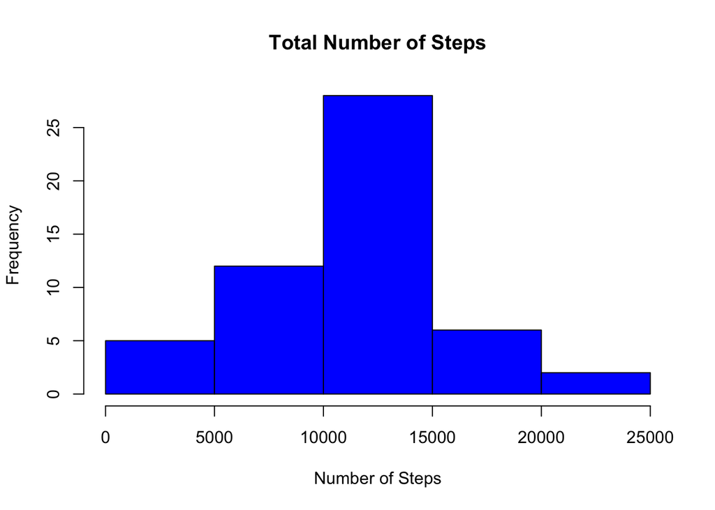

```r
hist(stepTotals$steps, breaks = 5, col = 4, axes = TRUE,
     main = "Total Number of Steps", xlab = "Number of Steps")
```

Calculate mean and median of the total number of steps taken per day

```r
avg <- mean(stepTotals$steps)
med <- median(stepTotals$steps)
#values are displayed in the text below
```

[output not shown]

# What is the average daily activity pattern?

Collapse data to a new data frame with the inteval and average number of steps

```r
intervals <- aggregate(data$steps ~ data$interval,FUN = mean)
colnames(intervals) <- c("interval","steps")
```

Graph the time series plot

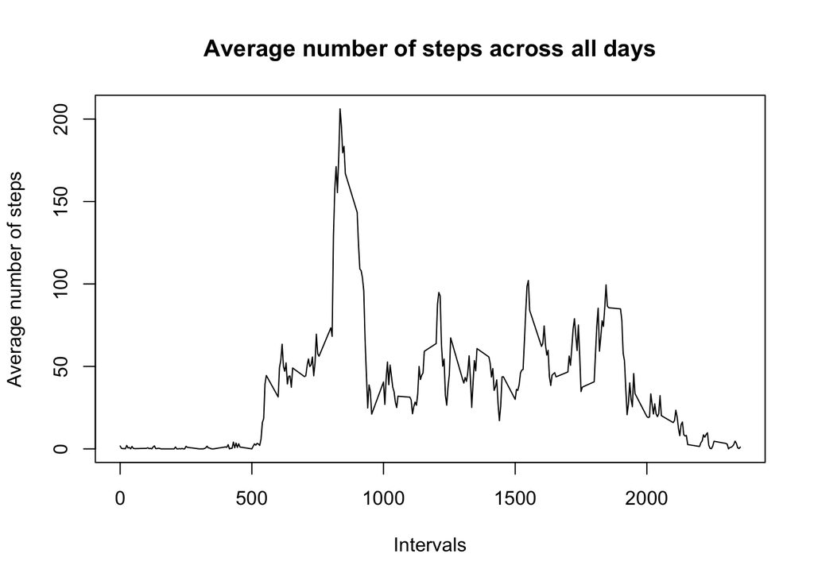

```r
plot(intervals$interval,intervals$steps, type = "l", col = 1,
     main = "Average number of steps across all days",
     xlab = "Intervals", ylab = "Average number of steps")
```

Find interval with maximum average number of steps

```r
maxSteps <-sort(intervals$steps, decreasing = TRUE)[1]
maxInt <- as.numeric(intervals[intervals$steps == maxSteps,][1])
#The value is embeded and displayed in the text below
```

The 5-minute interval at 835 contains the maximum number of steps of 206.1698113.

# Imputing missing values

Calculate and report the total number of missing values in the dataset (i.e. the total number of rows with NAs).

```r
#sum(is.na(data$date)) and sum(is.na(data$interval)) show
#that the only column with NA values is data$steps
numNA <- sum(is.na(data$steps))
```

The number of rows with NAs is 2304.

Now, I create a new dataset that is equal to the original dataset but with the missing data filled in. I replace NA with the average value for the given 5-minute interval across all the days. Average steps for each 5-minute interval are already caluclated in `intervals`.

```r
fillData <- data
for(i in 1:nrow(data))
{
    if(is.na(data$steps[i]))    #row is missing steps
    {
        #get the interval of that row
        interval_val <- data$interval[i]
        #find the row in intervals with the avg steps for interval_val
        row_val <- which(intervals$interval == interval_val)
        #find the number of steps in that row
        avgSteps <- intervals$steps[row_val]
        #replace the NA value
        fillData$steps[i] <- avgSteps
    }
}
#Check that we got all of them by sum(is.na(fillData$steps)) == 0
```

Add up steps on each day.

```r
fillStepTotals <- aggregate(fillData$steps ~ fillData$date, FUN = sum)
colnames(fillStepTotals) <- c("date","steps")
```

Make a histogram of the total number of steps taken each day.

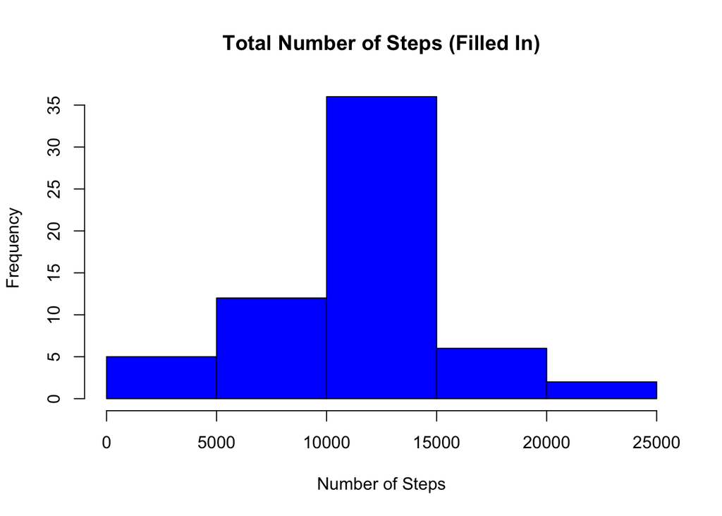

```r
hist(fillStepTotals$steps, breaks = 5, col = 4, axes = TRUE,
    main = "Total Number of Steps (Filled In)", xlab = "Number of Steps")
```

Calculate mean and median steps for the new filled in data.

```r
fillAvg <- mean(fillStepTotals$steps)
fillMed <- median(fillStepTotals$steps)
#values are displayed in the text below
```

[output not shown]

# Are there differences in activity patterns between weekdays and weekends?

The `weekdays()` function is helpful for this part. It takes a date and returns the day of the week as a string. We are using the filled dataset without missing values.

```r
 #Create a vector with the day of the week for each date.
day <- weekdays(as.Date(fillData$date))
dayType <- vector()
for(i in 1:nrow(fillData))  #fill the dayType vector based on day
{
    if(day[i] == "Saturday" || day[i] == "Sunday")
        dayType[i] <- "weekend"
    else
        dayType[i] <- "weekday"
}

fillData$dayType <- dayType
# make new column a factor variable with levels of "weekday" and "weekend"
fillData$dayType <- factor(fillData$dayType)
```

Create a table that has the average number of steps taken, averaged across all weekday days or weekend days, at each interval.

```r
intervalsByDay <- aggregate(steps ~ interval + dayType, data = fillData, FUN = mean)
#Take a look at the new table
head(intervalsByDay)
```

```
##   interval dayType      steps
## 1        0 weekday 2.25115304
## 2        5 weekday 0.44528302
## 3       10 weekday 0.17316562
## 4       15 weekday 0.19790356
## 5       20 weekday 0.09895178
## 6       25 weekday 1.59035639
```

Make a panel plot containing a time series plot of the average numeber of steps at each interval of that dayType. I am using the lattice plotting system.

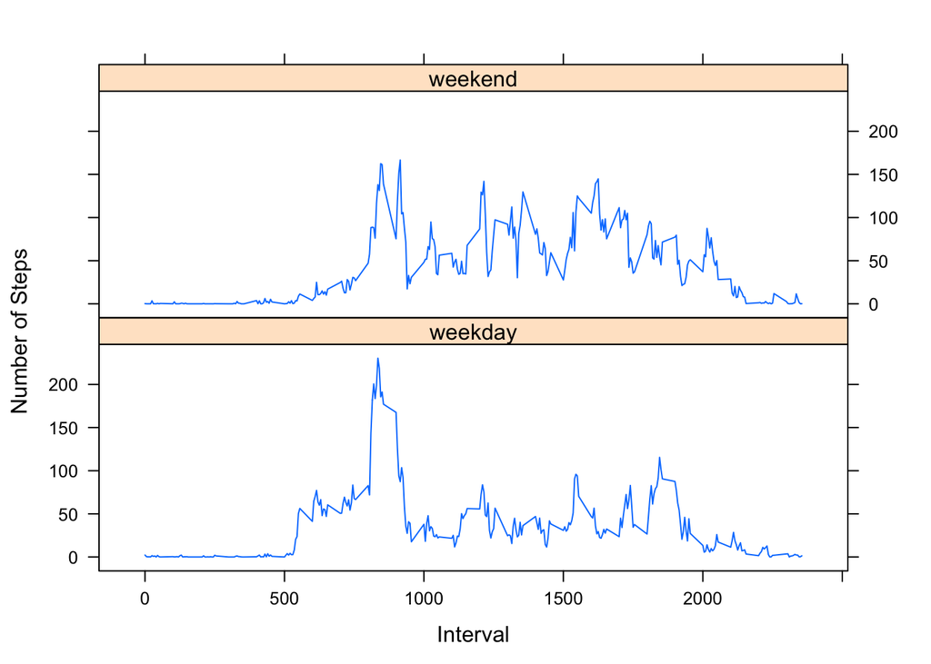

```r
library(lattice)
xyplot(steps ~ interval | dayType, data = intervalsByDay, type = "l", layout = c(1,2), xlab = "Interval", ylab = "Number of Steps")
```